# lista2-adar-Jestogon

Jéssica Stobienia Gonçalves

2024-10-24

1. Crie um vetor com os valores de $e^{x}cos{x}$ para os valores de $x = (3, 3.1, 3.2, ..., 6$).

```r
x_1 <- seq(from = 3, to = 6, by = 0.1)
x_1
 [1] 3.0 3.1 3.2 3.3 3.4 3.5 3.6 3.7 3.8 3.9 4.0 4.1 4.2 4.3 4.4 4.5 4.6 4.7 4.8
[20] 4.9 5.0 5.1 5.2 5.3 5.4 5.5 5.6 5.7 5.8 5.9 6.0
vetor_1 <- exp(x_1) * cos(x_1)
vetor_1
 [1] -19.884531 -22.178753 -24.490697 -26.773182 -28.969238 -31.011186
 [7] -32.819775 -34.303360 -35.357194 -35.862834 -35.687732 -34.685042
[13] -32.693695 -29.538816 -25.032529 -18.975233 -11.157417  -1.362099
[19]  10.632038  25.046705  42.099201  61.996630  84.929067 111.061586
[25] 140.525075 173.405776 209.733494 249.468441 292.486707 338.564378
[31] 387.360340
```

2. Crie os seguintes vetores.
   1. $(0.1^{3}\times0.2^{1}, 0.1^{6}\times0.2^{4}, ..., 0.1^{36}\times0.2^{34})$
   2. $(2, \frac{2^{2}}{2}, \frac{2^{3}}{3}, ..., \frac{2^{25}}{25})$

```r
(x_2 <- seq(from = 3, to = 36, by = 3))
 [1]  3  6  9 12 15 18 21 24 27 30 33 36
(y_2 <- x_2 - 2)
 [1]  1  4  7 10 13 16 19 22 25 28 31 34
vetor_2 <- 0.1^(x_2) * 0.2^(y_2)
vetor_2
 [1] 2.000000e-04 1.600000e-09 1.280000e-14 1.024000e-19 8.192000e-25
 [6] 6.553600e-30 5.242880e-35 4.194304e-40 3.355443e-45 2.684355e-50
[11] 2.147484e-55 1.717987e-60
```

```r
(x_3 <- seq(from = 2, to = 25, by = 1))
 [1]  2  3  4  5  6  7  8  9 10 11 12 13 14 15 16 17 18 19 20 21 22 23 24 25
vetor_3 <- 2^(x_3) / x_3
vetor_3
 [1] 2.000000e+00 2.666667e+00 4.000000e+00 6.400000e+00 1.066667e+01
 [6] 1.828571e+01 3.200000e+01 5.688889e+01 1.024000e+02 1.861818e+02
[11] 3.413333e+02 6.301538e+02 1.170286e+03 2.184533e+03 4.096000e+03
[16] 7.710118e+03 1.456356e+04 2.759411e+04 5.242880e+04 9.986438e+04
[21] 1.906502e+05 3.647221e+05 6.990507e+05 1.342177e+06
```

3. Reproduza a criação do vetor dias da semana (`dds`) mostrado abaixo.

```
domingo segunda   terca  quarta  quinta   sexta   sabado
      1       2       3       4       5       6        7
```

```r
dias <- c("domingo", "segunda", "terca", "quarta", "quinta", "sexta", "sabado")
dds <- c(1:7)
names(dds) <- dias
dds
domingo segunda   terca  quarta  quinta   sexta  sabado
      1       2       3       4       5       6       7
```

4. Interprete o resultado da seguinte operação:

```r
dds_nums <- c(
  5L, 2L, 5L, 2L, 7L, 7L, 2L,
  6L, 6L, 3L, 7L, 1L, 2L, 2L,
  5L, 7L, 3L, 2L, 6L, 4L, 1L
)
names(dds)[dds_nums]
```

Interpretação: através da indexação os valores inteiros do dds_nums representam os dias da semana.

5. Para um ano ser bissexto, ele deve ser:
- divísivel por 4 (a divisão é exata com resto igual a zero)
- não pode ser divisível por 100 (a divisão não é exata, ou seja, o resto é diferente de zero)
- pode ser que seja divisível por 400: caso seja divisível por 400, a divisão deve ser exata, deixando o resto igual a zero.

  Com os critérios definidos acima, construa o código para:
  1. Verificar se os anos 1894, 1947, 1901, 1992, 1925, 2014, 1993, 1996, 1984, 1897, 2100, 2300 são bissextos.
  2. Mostre quais anos são bissextos.
  3. Usando o código para verificar se o ano é bissexto, gere um vetor nomeado `ndias` com o número de dias do ano para os anos do item (a).
  4. Programe como obter o total de anos com 366 dias?

```r
anos <- c(1894, 1947, 1901, 1992, 1925, 2014, 1993, 1996, 1984, 1897, 2100, 2300)
bissextos <- (anos %% 4 == 0 & anos %% 100 != 0) | (anos %% 400 == 0)
bissextos
 [1] FALSE FALSE FALSE  TRUE FALSE FALSE FALSE  TRUE  TRUE FALSE FALSE FALSE
```

```r
anos[bissextos]
[1] 1992 1996 1984
```

```r
ndias <- ifelse(test = bissextos, yes = 366, no = 365)
names(ndias) <- anos
ndias
1894 1947 1901 1992 1925 2014 1993 1996 1984 1897 2100 2300
 365  365  365  366  365  365  365  366  366  365  365  365
```

```r
total_bissextos <- sum(bissextos)
total_bissextos
[1] 3
```

6. Quais códigos para gerar os seguintes dados:

```
[1] -30   0   5  10  15  20  30
```

```
[1] 1.0 0.8 0.6 0.4 0.2 0.0
```

```
[1] -3.1415927 -2.4434610 -1.7453293 -1.0471976 -0.3490659  0.3490659
[7]  1.0471976  1.7453293  2.4434610  3.1415927
```

```
[1] -1 -1  0  0  0  1  1  1  1  2  2  2  2  2  3  3  3  3  3  3  4  4  4
[24]  4  4  4  4  5  5  5  5  5  5  5  5
```

```
[1] 5 5 5 5 5 4 4 4 4 3 3 3 2 2 1 2 2 3 3 3 4 4 4 4 5 5 5 5 5
```

```r
x_5 <- c(-30, seq(0, 20, by = 5), 30)
x_5
[1] -30   0   5  10  15  20  30
```

```r
x_6 <- seq(1, 0, by = -0.2)
x_6
[1] 1.0 0.8 0.6 0.4 0.2 0.0
```

```r
x_7 <- seq(-pi, pi, by = 0.6981317)
x_7
 [1] -3.1415927 -2.4434610 -1.7453293 -1.0471976 -0.3490659  0.3490658
 [7]  1.0471975  1.7453292  2.4434609  3.1415926
```

```r
x_8 <- rep(-1:5, times = 2:8)
x_8
 [1] -1 -1  0  0  0  1  1  1  1  2  2  2  2  2  3  3  3  3  3  3  4  4  4  4  4
[26]  4  4  5  5  5  5  5  5  5  5
```

```r
x_9 <- c(rep(5:2, times = 5:2), 1, rep(2:5, times = 2:5))
x_9
 [1] 5 5 5 5 5 4 4 4 4 3 3 3 2 2 1 2 2 3 3 3 4 4 4 4 5 5 5 5 5
```

7. Usando o mesmo código para solução em todos os itens abaixo, obtenha as seguintes sequências usando os vetores fornecidos.
1. v3 = (11, 0.25, 7, 2)

```
[1] 1 2 3 4
```

2. v2 = (11, 0.25)

```
[1] 1 2
```

3. v1 = (11)

```
[1] 1
```

4. v0 = ()

```
integer(0)
```

```r
v3 <- c(11, 0.25, 7, 2)
seq_v3 <- seq_along(v3)
seq_v3
[1] 1 2 3 4
```

```r
v2 <- c(11, 0.25)
seq_v2 <- seq_along(v2)
seq_v2
[1] 1 2
```

```r
v1 <- c(11)
seq_v1 <- seq_along(v1)
seq_v1
[1] 1
```

```r
v0 <- c()
seq_v0 <- seq_along(v0)
seq_v0
integer(0)
```

8. Considere os seguintes dados horários de temperatura do ar ($T_{ar}$) registrados em duas estações meteorológicas, entre as 0 e 23 horas de um dado dia.

```r
tar_est1 <- c(
  14.92, 14.61, 14.32, 14.07, 13.84, 13.65, 13.56, 13.97, 15.08,
  16.5, 17.88, 19.08, 20.02, 20.66, 21.01, 21.05, 20.76, 20.05,
  18.77, 17.51, 16.67, 16.11, 15.66, 15.27
)
tar_est2 <- c(
  13.13, 13.01, 12.93, 12.87, 12.82, 12.81, 13.2, 14.22, 15.77,
  17.49, 19.2, 20.57, 21.49, 22.01, 22.03, 21.71, 20.84, 18.77,
  16.54, 15.13, 14.34, 13.81, 13.49, 13.28
)
```

> Dica: Faça um gráfico para visualizar as temperaturas das duas estações. Isso facilitará a solução.

**a.** Determine a média diária da $T_{ar}$ das duas estações arrendondando para uma casa decimal. Salve a média de cada estação nas variáveis `tmed_est1` e `tmed_est2`.

**b**. Utilizando as variáveis do item anterior, verifique usando comparação lógica, em qual estação o ambiente é mais quente?

**c**. Obtenha a 3ª maior temperatura do dia em cada estação.

**d**. Calcule a amplitude térmica diária ($ATD = T_{max}-T_{min}$, onde $T_{max}$: temperatura máxima dária e $T_{min}$: temperatura mínima dária) das estações 1 e 2, arrendondando para uma casa decimal. Salve os resultados nas variaveis `atd_est1` e `atd_est2`.

**e**. Qual o horário de ocorrência das temperaturas máximas e mínimas em cada estação? Salve os resultados nas variáveis `hmax_est{i}` e `hmin_est{i}`, com $i = 1, 2$.

**f**. Quando `tar_est2` é maior que `tar_est1` qual a maior diferença absoluta de temperatura entre as duas estações?

**g**. Qual a hora correspondende a ocorrência daquela maior diferença absoluta de temperatura obtida no item anterior?

**h**. O horário do pôr do sol pode ser estimado a partir da $T_{ar}$. Para o período após o horário de ocorrência da $T_{max}$ determina-se em qual hora ocorre a maior queda de $T_{ar}$ em relação a hora anterior. Estime o horário do pôr do sol para as duas estações (`hps_est{i}`).

**i**. Em quais horas as temperaturas das duas estações estão mais próximas uma da outra, ou seja com menos de 0,5°C de diferença ?

**j**. Calcule a temperatura média diária usando os seguintes métodos para estação 2.

$T_{med_{1}} = (T_{max} + T_{min})/2$, salvando em uma variável `tar_met1`.

$T_{med_{2}} = (T_{max} + T_{min} + T_{9} + 2T_{21})/5$, salvando em uma variável `tar_met2`.

$T_{med_{3}} = (T_{7} + T_{14} + 2T_{21})/4$, salvando em uma variável `tar_met2`.

Compare este resultados com aqueles obtidos no item **a**. Qual é melhor?

```r
(tmed_est1 <- round(mean(tar_est1), 1))
[1] 16.9
(tmed_est2 <- round(mean(tar_est2), 1))
[1] 16.3
```

```r
medias <- c(tmed_est1, tmed_est2)
names(medias) <- c("tmed_est1", "tmed_est2")
medias[which.max(medias)]
tmed_est1
     16.9
```

```r
(terceira_maiorT_est1 <- sort(tar_est1, decreasing = TRUE)[3])
[1] 20.76
(terceira_maiorT_est2 <- sort(tar_est2, decreasing = TRUE)[3])
[1] 21.71
```

```r
Tmax2 <- max(tar_est2)
Tmax1 <- max(tar_est1)
Tmin2 <- min(tar_est2)
Tmin1 <- min(tar_est1)

(atd_est1 <- round(Tmax1 - Tmin1, 1))
[1] 7.5
(atd_est2 <- round(Tmax2 - Tmin2, 1))
[1] 9.2
```

```r
temps <- list(tar_est1, tar_est2)
hmax_est <- list()
hmin_est <- list()
for (i in 1:2) {
  hmax_est[[i]] <- which.max(temps[[i]])
  hmin_est[[i]] <- which.min(temps[[i]])
}
names(hmax_est) <- paste0("hmax_ext", 1:2)
names(hmin_est) <- paste0("hmim_ext", 1:2)
hmax_est
$hmax_ext1
[1] 16

$hmax_ext2
[1] 15
hmin_est
$hmim_ext1
[1] 7

$hmim_ext2
[1] 6

#salvar as variáveis separadamente:
for (i in 1:2) {
  assign(paste0("hmax_est", i), which.max(temps[[i]]))
  assign(paste0("hmin_est", i), which.min(temps[[i]]))
}
```

```r
diferencas <- abs(tar_est2 - tar_est1)
dif_valida <- diferencas[tar_est2 > tar_est1]
maior_dif <- max(dif_valida)
maior_dif
[1] 1.49
```

```r
horas <- 0:23
indice_maior_dif <- which(diferencas == maior_dif & tar_est2 > tar_est1)
hora_maior_dif <- horas[indice_maior_dif]
hora_maior_dif
[1] 11
maior_dif
[1] 1.49
```

```r
horario_ps <- list()
for (i in 1:2){
  queda_temp <- diff(temps[[i]][(hmax_est[[i]] + 1):length(temps[[i]])])
  maior_queda <- which.min(queda_temp)
  horario_ps[[i]] <- (hmax_est[[i]] + maior_queda)
}
names(horario_ps) <- paste0("horario_ps", 1:2)
horario_ps
$horario_ps1
[1] 18

$horario_ps2
[1] 18
```

```r
(horas_proximas <- horas[diferencas < 0.5])
[1]  6  7 16
```

```r
T9 <- tar_est2[9]
T21 <- tar_est2[21]
T7 <- tar_est2[7]
T14 <- tar_est2[14]

tar_met1 <- (Tmax2 + Tmin2) / 2
tar_met2 <- (Tmax2 + Tmin2 + T9 + 2 * T21) / 5
tar_met3 <- (T7 + T14 + 2 * T21) / 4

tar_met1
[1] 17.42
tar_met2
[1] 15.858
tar_met3
[1] 15.9725
```

Comparação de resultados:

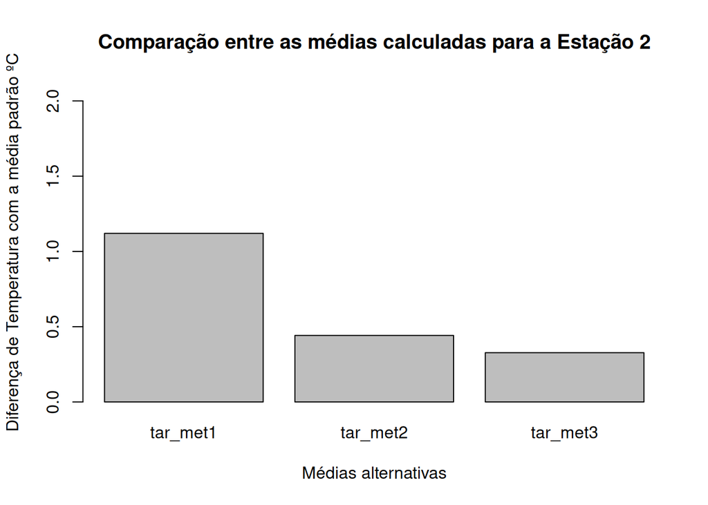

```r
valor_dif_medias2 <- abs(c(tar_met1, tar_met2, tar_met3) - tmed_est2)
names(valor_dif_medias2) <- c("tar_met1", "tar_met2", "tar_met3")
barplot(valor_dif_medias2,
        xlab = "Médias alternativas",
        ylab = "Diferença de Temperatura com a média padrão ºC",
        main = "Comparação entre as médias calculadas para a Estação 2",
        ylim = c(0, max(valor_dif_medias2) + 1))
```

```r
valor_dif_medias2[which.min(valor_dif_medias2)]
tar_met3
  0.3275
```

O melhor resultado é aquele que apresenta a menor diferença em relação a média padrão, ou seja, tar_met3

9. Calcule a temperatura do ar horária usando o **modelo de onda** para representação do ciclo diário da temperatura do ar, descrito pelas seguintes equações:

$$\left\{\begin{matrix}
h_{T_{min}}\leq h < h_{T_{max}}, & T_{calc} = \bar{T} - A \,
cos\left ( arg \right )\\
demais\; horas, & T_{calc} = \bar{T} + A \, cos\left ( arg \right )
\end{matrix}\right.$$

onde:

$$\bar{T} = \left ( \frac{T_{max} +
T_{min}}{2} \right )$$

e

$$A =\left ( \frac{T_{max}-T_{min}}{2}
\right )$$

O argumento do cosseno ($arg$) é definido por:

$$\left\{\begin{matrix}
h < h_{T_{min}}, & arg = \pi \left ( \frac{h+10}{10+h_{Tmin}}
\right )\\
h_{T_{min}}\leq h < h_{T_{max}}, & arg = \pi \left (
\frac{h-h_{T_{min}}}{14-h_{T_{min}}} \right )\\
h > h_{T_{max}}, & arg = \pi\left ( \frac{14-h}{10+h_{Tmin}}
\right )
\end{matrix}\right.$$

**a**. Aplique o método acima para estação 1 e 2 substituindo os valores de $T_{max}$, $T_{min}$, $h_{T_{max}}$, $h_{T_{max}}$, adequadamente.

**b**. Calcule o RMSE nos dois casos. $RMSE = \sqrt{\frac{1}{n}\sum_{i=1}^{n}\left (T_{calc}-T_{obs} \right )^{2}}$

**c**. Calcule a correlação ($r$) nos dois casos. A barra representa a média aritmética.

$$r = \frac{\sum_{i=1}^{n}
(T_{obs}-\bar{T}_{obs})(T_{calc}-\bar{T}_{calc}))}{\sqrt{\sum_{i =
1}^{n}
(T_{obs}-\bar{T}_{obs})^{2}(T_{calc}-\bar{T}_{calc})^{2})}}$$

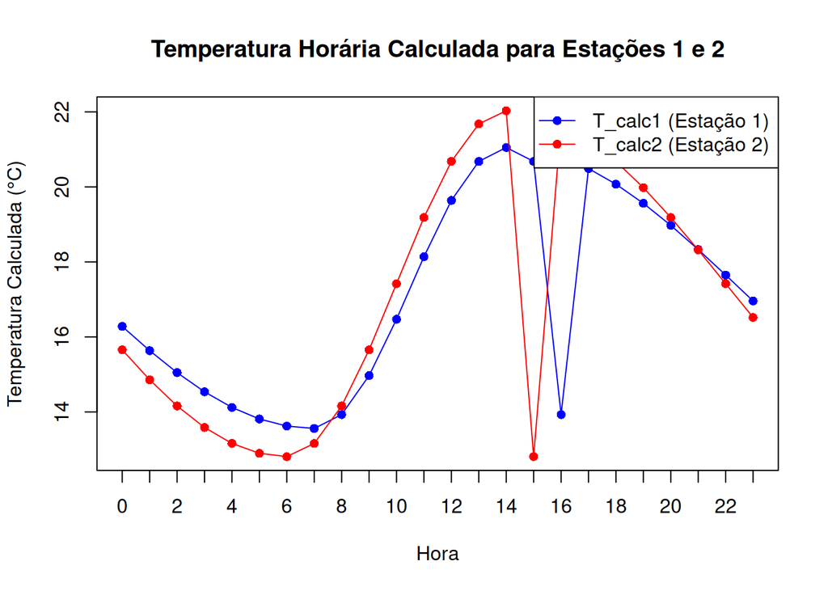

```r
calcula_Tcalc <- function(Tmax, Tmin, hmax_est, hmin_est) {
  T_media <- (Tmax + Tmin) / 2
  A <- (Tmax - Tmin) / 2
  T_calc <- numeric(24)

  for (h in 0:23) {
    if (h < hmin_est) {
      arg <- (h + 10) / (10 + hmin_est)
    } else if (h >= hmin_est & h < hmax_est) {
      arg <- (h - hmin_est) / (14 - hmin_est)
    } else if (h > hmax_est){
      arg <- (14 - h) / (10 + hmin_est)
    }

    if (h >= hmin_est & h < hmax_est) {
      T_calc[h + 1] <- T_media - A * cos(pi * arg)
    } else {
      T_calc[h + 1] <- T_media + A * cos(pi * arg)
    }
  }
  return(T_calc)
}

# Aplicando o método para as duas estações
T_calc1 <- calcula_Tcalc(Tmax1, Tmin1, hmax_est1, hmin_est1)
T_calc1
 [1] 16.28013 15.63571 15.04813 14.53741 14.12094 13.81289 13.62377 13.56000
 [9] 13.93087 14.97003 16.47166 18.13834 19.63997 20.67913 21.05000 20.67913
[17] 13.93087 20.48906 20.07259 19.56187 18.97429 18.32987 17.65055 16.95945
T_calc2 <- calcula_Tcalc(Tmax2, Tmin2, hmax_est2, hmin_est2)
T_calc2
 [1] 15.65583 14.85882 14.16024 13.58693 13.16092 12.89858 12.81000 13.16092
 [9] 14.16024 15.65583 17.42000 19.18417 20.67976 21.67908 22.03000 12.81000
[17] 21.67908 21.25307 20.67976 19.98118 19.18417 18.31937 17.42000 16.52063

# Plotando T_calc1 e T_calc2
plot(horas, T_calc1,
     type = "o",
     col = "blue",
     pch = 16,
     ylim = range(c(T_calc1, T_calc2)),
     xlab = "Hora",
     ylab = "Temperatura Calculada (°C)",
     main = "Temperatura Horária Calculada para Estações 1 e 2",
     xaxt = "n")
axis(1,
     at = horas,
     labels = horas)
lines(horas, T_calc2,
      type = "o",
      col = "red",
      pch = 16)
legend("topright",
       legend = c("T_calc1 (Estação 1)", "T_calc2 (Estação 2)"),
       col = c("blue", "red"),
       pch = 16,
       lty = 1)
```

```r
rmse <- function(T_obs, T_calc) {
  sqrt(mean((T_calc - T_obs) ^ 2))
}

RMSE1 <- rmse(tar_est1, T_calc1)
RMSE1
[1] 1.83183
RMSE2 <- rmse(tar_est2, T_calc2)
RMSE2
[1] 3.038173
```

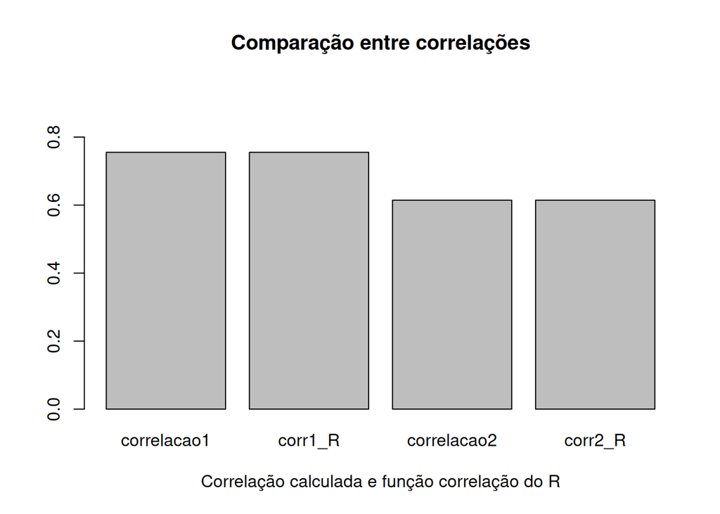

```r
calcula_correlacao <- function(tar_est, tmed_est, T_calc) {
  mean_calc <- mean(T_calc)

  numerador <- sum((tar_est - tmed_est) * (T_calc - mean_calc))
  denominador <- sqrt(sum((tar_est - tmed_est)^2) * sum((T_calc - mean_calc)^2))

  # Calculando a correlação
  r_manual <- numerador / denominador

  # Retornando o valor da correlação
  return(r_manual)
}

(corr1_R <- cor(tar_est1, T_calc1))
[1] 0.7552633
(correlacao1 <- calcula_correlacao(tar_est1, tmed_est1, T_calc1))
[1] 0.755231
(corr2_R <- cor(tar_est2, T_calc2))
[1] 0.6144771
(correlacao2 <- calcula_correlacao(tar_est2, tmed_est2, T_calc2))
[1] 0.6144741

dif_correlacoes <- abs(c(correlacao1, corr1_R, correlacao2, corr2_R))
names(dif_correlacoes) <- c("correlacao1", "corr1_R", "correlacao2", "corr2_R")
barplot(dif_correlacoes,
        xlab = "Correlação calculada e função correlação do R",
        main = "Comparação entre correlações",
        ylim = c(0, max(dif_correlacoes) + 0.2))
```